# Statistical machine learning, Lab 11

# Classical methods for classification

The aim of this lab is to learn to use R for fitting classical methods for classification and analyzing fit

## Fitting a logistic regression model

Logistic regression is a special case of more general class of generalized linear models and can be fitted with `glm` command, supplying parameter `family=binomial()`. Using this command is similar to fitting linear model with `lm()` command. In the `tidymodels` framework, logistic regression model can be specified with `logistic_reg()` command, which can later be fitted by constructing appropriate workflow and using `fit()` command for that workflow. It is important to take into account that `glm` command allows the response variable to be either numeric (0 or 1) or a factor variable; in `tidymodels` framework fitting `logistic_reg()` models requires the outcome to be a factor variable with two levels.

- **Exercise 1**. Let us use `iris` dataset for practicing classification with `glm()
  - Look at pairwise plots of the first four columns of the dataset by using the column `Species` for indicating colors. Use the command `ggpairs` from the library `GGally` with `mapping=aes(color=Species)` and `columns=1:4` parameters for producing the plots. Based on those plots, should we expect to get good classifiers based on the data?

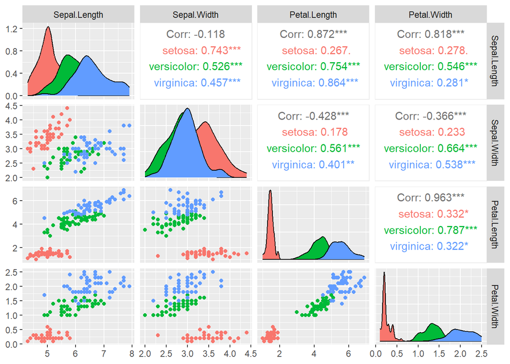

    ```r
    ggpairs(iris,aes(color=Species),columns=1:4,progress=FALSE)
    ```

  - Form dataset `iris_mod` by adding variables `Species_setosa`,`Species_virginica` and `Species_versicolor`, which are 1 if observation is from corresponding species and 0 otherwise

    ```r
    rec_dummies=recipe(~.,data=iris)|>step_dummy(Species,one_hot=TRUE)
    rec_dummies_prepared=rec_dummies|>prep()
    iris_mod=rec_dummies_prepared |>bake(new_data=iris)
    #iris_mod = mutate(iris,virginica=if_else(Species=="virginica",1,0),versicolor=if_else(Species=="versicolor",1,0),setosa=if_else(Species=="setosa",1,0))
    ```

  - Fit a logistic regression model to the variable `Species_virginica` by using `Petal.Length` and `Petal.Width` for regressors.

    ```r
    model1.1=glm(Species_virginica~Petal.Length+Petal.Width,data=iris_mod,family=binomial())
    tidy(model1.1)
    ```

    | term | estimate | std.error | statistic | p.value |
    | --- | --- | --- | --- | --- |
    | (Intercept) | -45.272344 | 13.611432 | -3.326053 | 0.0008808521 |
    | Petal.Length | 5.754532 | 2.305879 | 2.495592 | 0.0125747247 |
    | Petal.Width | 10.446700 | 3.755610 | 2.781625 | 0.0054087434 |

    ```r
    glance(model1.1)
    ```

    | null.deviance | df.null | logLik | AIC | BIC | deviance | df.residual | nobs |
    | --- | --- | --- | --- | --- | --- | --- | --- |
    | 190.9543 | 149 | -10.28175 | 26.56351 | 35.59541 | 20.56351 | 147 | 150 |

- **Exercise 2** Fitting logistic regression models with tidymodels framework.
  - Fit a logistic regression model to the variable `Species_virginica` by using `Petal.Length`, `Petal.Width`, `Sepal.Length`, `Sepal.Width` for regressors by using `tidymodels` framework. For that, define a new data set iris_mod2, where `Species_virginica` is changed to a factor variable, use `logistic_reg()` to define model specification, a recipe indicating outcome and predictors and workflow involving both recipe and model specification. Can we consider this model better than the previous one?

    ```r
    iris_mod2=recipe(~.,data=iris_mod)|>step_bin2factor(starts_with("Species_"))|>prep()|>bake(new_data=NULL)
    rec2=recipe(Species_virginica~Petal.Length+Petal.Width+Sepal.Length+Sepal.Width,data=iris_mod2)
    mod_spec2=logistic_reg()
    wf2=workflow()|>add_model(mod_spec2)|>add_recipe(rec2)
    wf2_fitted=wf2|>fit(iris_mod2)
    tidy(wf2_fitted)
    ```

    | term | estimate | std.error | statistic | p.value |
    | --- | --- | --- | --- | --- |
    | (Intercept) | 42.637804 | 25.707596 | 1.658568 | 0.09720282 |
    | Petal.Length | -9.429385 | 4.737195 | -1.990500 | 0.04653593 |
    | Petal.Width | -18.286137 | 9.742594 | -1.876927 | 0.06052811 |
    | Sepal.Length | 2.465220 | 2.394300 | 1.029621 | 0.30318813 |
    | Sepal.Width | 6.680887 | 4.479558 | 1.491416 | 0.13585218 |

    ```r
    glance(wf2_fitted)
    ```

    | null.deviance | df.null | logLik | AIC | BIC | deviance | df.residual | nobs |
    | --- | --- | --- | --- | --- | --- | --- | --- |
    | 190.9543 | 149 | -5.949273 | 21.89855 | 36.95172 | 11.89855 | 145 | 150 |

    ```r
    summary(extract_fit_engine(wf2_fitted))
    ```

    ```
    ##
    ## Call:
    ## stats::glm(formula = ..y ~ ., family = stats::binomial, data = data)
    ##
    ## Coefficients:
    ##              Estimate Std. Error z value Pr(>|z|)
    ## (Intercept)    42.638     25.708   1.659   0.0972 .
    ## Petal.Length   -9.429      4.737  -1.990   0.0465 *
    ## Petal.Width   -18.286      9.743  -1.877   0.0605 .
    ## Sepal.Length    2.465      2.394   1.030   0.3032
    ## Sepal.Width     6.681      4.480   1.491   0.1359
    ## ---
    ## Signif. codes:  0 '***' 0.001 '**' 0.01 '*' 0.05 '.' 0.1 ' ' 1
    ##
    ## (Dispersion parameter for binomial family taken to be 1)
    ##
    ##     Null deviance: 190.954  on 149  degrees of freedom
    ## Residual deviance:  11.899  on 145  degrees of freedom
    ## AIC: 21.899
    ##
    ## Number of Fisher Scoring iterations: 12
    ```

  - Look at the box plot of computed probabilities for each group. To have predicted probabilities attached to data frame, it is possible to add a variable with `mutate(new_var=predict(model,type="response"))` or use `augment(model, type.predict="response")` or use `augment(fitted_workflow,new_data=data)` if a workflow was fitted. Look also at the point plot of `Petal.Length` vs `Petal.Width`, where different species are denoted with different symbols (inside `aes()` use `symbol=Species`) and color indicated with predicted probability.

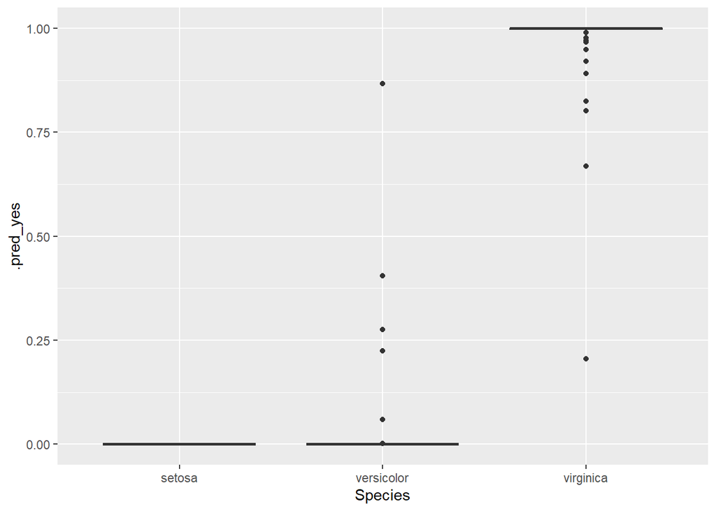

    ```r
    data_pred=augment(wf2_fitted,new_data=iris)
    ggplot(data_pred)+geom_boxplot(aes(x=Species,y=.pred_yes))
    ```

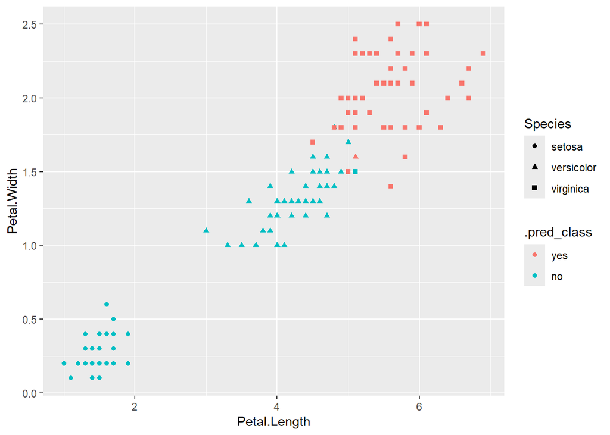

    ```r
    ggplot(data_pred)+geom_point(aes(x=Petal.Length,y=Petal.Width,shape=Species,color=.pred_class))
    ```

  - If we fit a logistic regression model, then we can construct different classifiers by predicting class for level 1 when estimated probability for that level is larger than a cut-off value $a$ and class of level 0 otherwise. When we want to minimize classification errors then for correct estimates of the probability the best cut-off value is 0.5 and often the classification by logistic regression is done according to this level. Use `conf_mat()` command to find the confusion matrix in the case we use default classification rule in the case of iris data. Also find confusion matrix when we consider the error of predicting incorrectly class 1 is 4 times smaller than predicting incorrectly class 0 (cutoff is then $\frac{1}{5}$).

    ```r
    data_pred=augment(wf2_fitted,new_data=iris_mod2)
    data_pred|>conf_mat(Species_virginica,.pred_class)
    ```

    ```
    ##           Truth
    ## Prediction yes no
    ##        yes  49  1
    ##        no    1 99
    ```

    ```r
    data_pred|>mutate(.pred_class=factor(if_else(.pred_yes>1/5,"yes","no"),levels=c("yes","no")))|>conf_mat(Species_virginica,.pred_class)
    ```

    ```
    ##           Truth
    ## Prediction yes no
    ##        yes  50  4
    ##        no    0 96
    ```

  - Fit a model for `Species_versicolor` with respect to `Petal.Length` and `Petal.Width`. Form confusion matrix of predictions. What is the number of prediction errors? Is the model working well?

    ```r
    rec3=recipe(Species_versicolor~Petal.Length+Petal.Width,data=iris_mod2)
    wf3=workflow()|>add_recipe(rec3)|> add_model(logistic_reg())
    model1.3=wf3|> fit(data=iris_mod2)#glm(Species_versicolor~Petal.Length+Petal.Width,data=iris_mod,family=binomial())
    summary(model1.3)
    ```

    ```
    ##         Length Class      Mode
    ## pre     3      stage_pre  list
    ## fit     2      stage_fit  list
    ## post    1      stage_post list
    ## trained 1      -none-     logical
    ```

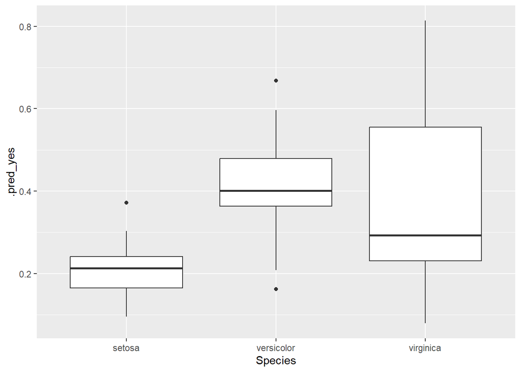

    ```r
    ggplot(augment(model1.3,iris))+geom_boxplot(aes(x=Species,y=.pred_yes))
    ```

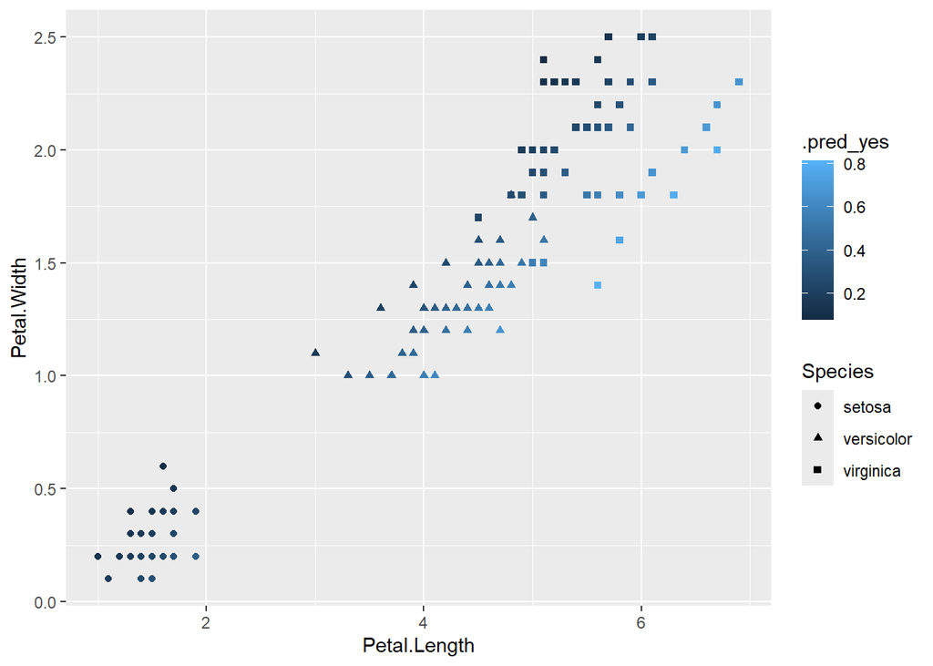

    ```r
    ggplot(augment(model1.3,iris))+geom_point(aes(x=Petal.Length,y=Petal.Width,shape=Species,color=.pred_yes))
    ```

    ```r
    augment(model1.3,iris_mod2)|>conf_mat(truth=Species_versicolor,estimate=.pred_class)
    ```

    ```
    ##           Truth
    ## Prediction yes no
    ##        yes  12 16
    ##        no   38 84
    ```

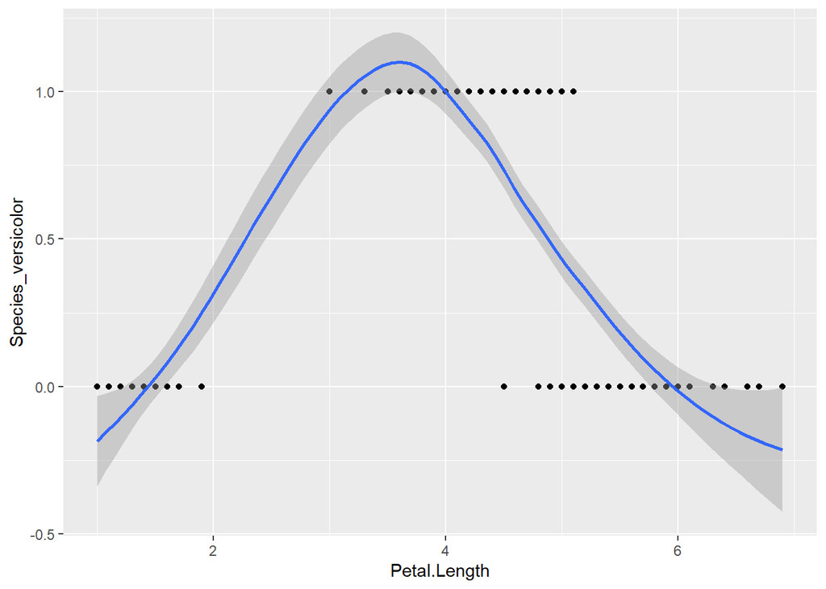

    ```r
    ggplot(iris_mod,aes(x=Petal.Length,y=Species_versicolor))+geom_point()+geom_smooth()
    ```

    ```r
    #data3=iris_mod|>mutate(versicolor=factor(versicolor))
    data3=iris_mod2
    rec3=recipe(Species_versicolor~Petal.Length+Petal.Width,data=data3)|>step_poly(Petal.Length,degree = 2)
    wf3=workflow()|>add_recipe(rec3)|>add_model(logistic_reg())
    wf3_fitted=wf3|>fit(data=data3)
    augment(wf3_fitted,new_data=data3)|>conf_mat(Species_versicolor,.pred_class)
    ```

    ```
    ##           Truth
    ## Prediction yes no
    ##        yes  47  3
    ##        no    3 97
    ```

    ```r
    glance(wf3_fitted)
    ```

    | null.deviance | df.null | logLik | AIC | BIC | deviance | df.residual | nobs |
    | --- | --- | --- | --- | --- | --- | --- | --- |
    | 190.9543 | 149 | -9.963087 | 27.92617 | 39.96871 | 19.92617 | 146 | 150 |

    ```r
    rec4=recipe(Species_versicolor~Petal.Length+Petal.Width,data=data3)|>step_ns(Petal.Length,deg_free = 2)
    wf4=workflow()|>add_recipe(rec4)|>add_model(logistic_reg())
    wf4_fitted=wf4|>fit(data=data3)
    augment(wf4_fitted,new_data=data3)|>conf_mat(Species_versicolor,.pred_class)
    ```

    ```
    ##           Truth
    ## Prediction yes no
    ##        yes  47  3
    ##        no    3 97
    ```

    ```r
    glance(wf4_fitted)
    ```

    | null.deviance | df.null | logLik | AIC | BIC | deviance | df.residual | nobs |
    | --- | --- | --- | --- | --- | --- | --- | --- |
    | 190.9543 | 149 | -10.14751 | 28.29501 | 40.33755 | 20.29501 | 146 | 150 |

  - Fit a logistic regression model for `Species_setosa` with respect to `Petal.Length`. Do you understand why parameter estimates have very large errors? Is the model still good for classification?

    ```r
    model1.5=glm(Species_setosa~Petal.Length,data=iris_mod,family=binomial())
    tidy(model1.5)
    ```

    | term | estimate | std.error | statistic | p.value |
    | --- | --- | --- | --- | --- |
    | (Intercept) | 91.67164 | 47334.35 | 0.001936683 | 0.9984548 |
    | Petal.Length | -37.22296 | 18357.58 | -0.002027662 | 0.9983822 |

## Fitting linear discriminant analysis models

Command for fitting Linear Discriminant Analysis model is `lda()` in the `MASS` library. Unfortunately some commands in this library overwrite corresponding commands from `tidyverse`, which may cause problems if we want to manipulate data frames. So, instead of loading this library , I recommend to use use the command in the form `MASS::lda()`. The predictions for classes can be obtained by `predict(model)$class` and computed class probabilities can be obtained by `predict(model)$posterior`. Note that the methods may not work if some classes have several locations of concentration. In order to fit the same model using `tidymodels` framework, one should install the package `discrim` and use the command `discrim_linear()`.

- **Exercise 3** We continue working with `iris` data set.
  - Fit LDA model for Species in terms of `Petal.Length` and `Petal.Width`. How many prediction errors this method makes on training set?

    ```r
    model2.1 = MASS::lda(Species~Petal.Length+Petal.Width,data=iris)
    model2.1
    ```

    ```
    ## Call:
    ## lda(Species ~ Petal.Length + Petal.Width, data = iris)
    ##
    ## Prior probabilities of groups:
    ##     setosa versicolor  virginica
    ##  0.3333333  0.3333333  0.3333333
    ##
    ## Group means:
    ##            Petal.Length Petal.Width
    ## setosa            1.462       0.246
    ## versicolor        4.260       1.326
    ## virginica         5.552       2.026
    ##
    ## Coefficients of linear discriminants:
    ##                   LD1       LD2
    ## Petal.Length 1.544371 -2.161222
    ## Petal.Width  2.402394  5.042599
    ##
    ## Proportion of trace:
    ##    LD1    LD2
    ## 0.9947 0.0053
    ```

    ```r
    iris |> mutate(prediction=predict(model2.1)$class)|> select(Species,prediction)|> table()
    ```

    ```
    ##             prediction
    ## Species      setosa versicolor virginica
    ##   setosa         50          0         0
    ##   versicolor      0         48         2
    ##   virginica       0          4        46
    ```

  - Fit LDA model by using all predictors. What is the number of classifying errors in this case?

    ```r
    model2.2 = MASS::lda(Species~.,data=iris)
    model2.2
    ```

    ```
    ## Call:
    ## lda(Species ~ ., data = iris)
    ##
    ## Prior probabilities of groups:
    ##     setosa versicolor  virginica
    ##  0.3333333  0.3333333  0.3333333
    ##
    ## Group means:
    ##            Sepal.Length Sepal.Width Petal.Length Petal.Width
    ## setosa            5.006       3.428        1.462       0.246
    ## versicolor        5.936       2.770        4.260       1.326
    ## virginica         6.588       2.974        5.552       2.026
    ##
    ## Coefficients of linear discriminants:
    ##                     LD1         LD2
    ## Sepal.Length  0.8293776 -0.02410215
    ## Sepal.Width   1.5344731 -2.16452123
    ## Petal.Length -2.2012117  0.93192121
    ## Petal.Width  -2.8104603 -2.83918785
    ##
    ## Proportion of trace:
    ##    LD1    LD2
    ## 0.9912 0.0088
    ```

    ```r
    iris |> mutate(prediction=predict(model2.2)$class)|> conf_mat(Species,prediction)
    ```

    ```
    ##             Truth
    ## Prediction   setosa versicolor virginica
    ##   setosa         50          0         0
    ##   versicolor      0         48         1
    ##   virginica       0          2        49
    ```

## Quadratic discriminant analysis

For fitting quadratic discriminant analysis model we use tidymodels framework with `discrim_quad()` from `discrim`package.

- **Exercise 4** Fit both LDA and QDA models to dataset `Lab11_data.csv` by using tidymodels framework. Compute confusion matrix for both methods using predictions on the same data which was used for fitting. Produce also a plot which shows how prediction class changes by forming a set of new values for predictors which cover the smallest rectangular area covering the original data. (Hint - commands `seq` and `expand_grid` may simplify creation of this data set)

*Solution:*

```r
  Lab11_data=read_csv("Lab11_data.csv",col_types="nnf")
  colnames(Lab11_data)[3]<-"Class"
  spec_lda=discrim_linear()
  rec_lda=recipe(Class~X1+X2,data=Lab11_data)
  wf_lda=workflow()|>add_recipe(rec_lda)|>add_model(spec_lda)
  wf_lda_fitted=wf_lda|>fit(Lab11_data)#lda(default~income+balance,data=Default)
  pred_lda=augment(wf_lda_fitted,new_data=Lab11_data)
  conf_mat(pred_lda,truth=Class,estimate=.pred_class)
```

```
##           Truth
## Prediction   1   2   3
##          1 144   3   2
##          2  16 234   0
##          3   0   3 118
```

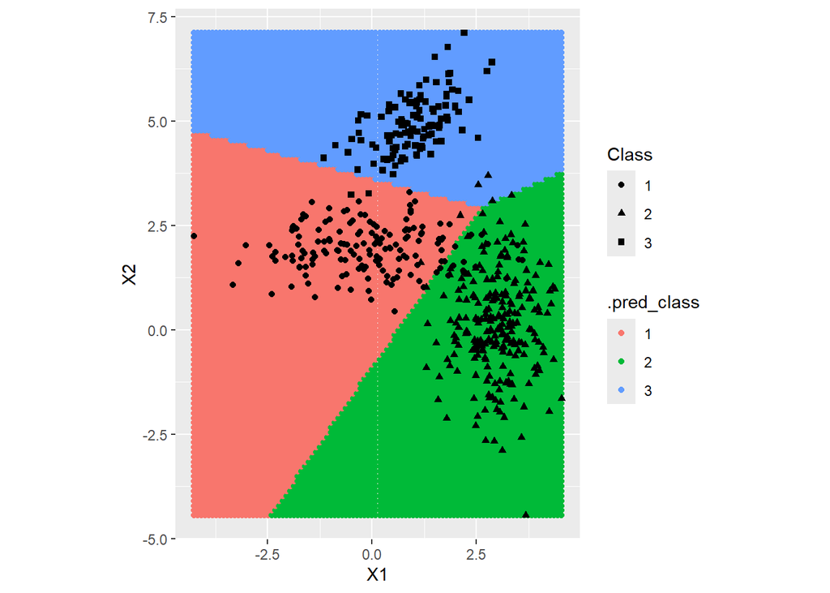

```r
  npoints=100
  X1=seq(min(Lab11_data$X1),max(Lab11_data$X1),length.out=npoints)
  X2=seq(min(Lab11_data$X2),max(Lab11_data$X2),length.out=npoints)
  pred_data=expand_grid(X1,X2)
  ggplot(augment(wf_lda_fitted,new_data=pred_data),aes(x=X1,y=X2,color=.pred_class))+geom_point()+geom_point(data=Lab11_data,aes(x=X1,y=X2,shape=Class),color="black")+coord_fixed()
```

```r
  spec_qda=discrim_quad()
  rec_qda=recipe(Class~X1+X2,data=Lab11_data)
  wf_qda=workflow()|>add_recipe(rec_qda)|>add_model(spec_qda)
  wf_qda_fitted=wf_qda|>fit(Lab11_data)#lda(default~income+balance,data=Default)
  conf_mat(augment(wf_qda_fitted,new_data=Lab11_data),truth=Class,estimate=.pred_class)
```

```
##           Truth
## Prediction   1   2   3
##          1 149   6   0
##          2  11 234   0
##          3   0   0 120
```

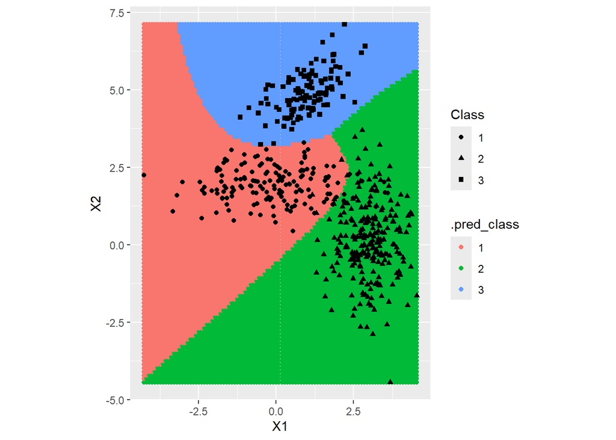

```r
  ggplot(augment(wf_qda_fitted,new_data=pred_data),aes(x=X1,y=X2,color=.pred_class))+geom_point()+geom_point(data=Lab11_data,aes(x=X1,y=X2,shape=Class),color="black")+coord_fixed()
```

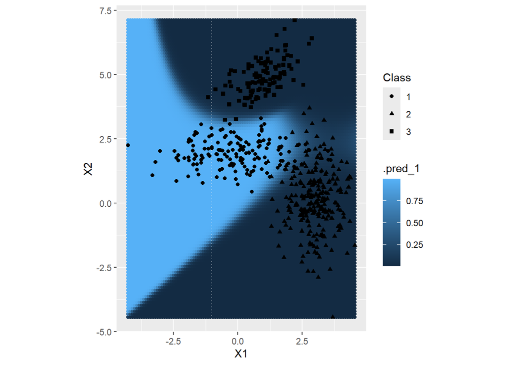

```r
  #plot for predicted probability of class 1
  ggplot(augment(wf_qda_fitted,new_data=pred_data),aes(x=X1,y=X2,color=.pred_1))+geom_point()+geom_point(data=Lab11_data,aes(x=X1,y=X2,shape=Class),color="black")+coord_fixed()
```